# An Analysis of the London Marathon (2014-2019)

Elliot Quan

January 21, 2020

# Introduction

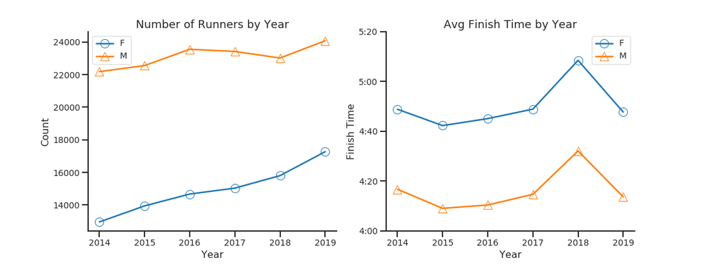

The immediate question that jumps to mind is what happened in 2018? According to marathon officials, 2018 reached the highest temperature in the race’s history (23C/73F). It’s no surprise that temperature has a measured [negative effect](https://www.medscape.com/viewarticle/555022) on running performance, even moreso with longer races.

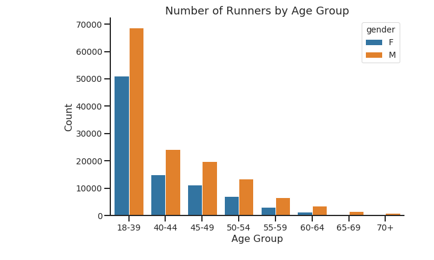

If you’re new to the marathon or running in general, you might think that it’s a young person’s sport. However 48% of the 230,000+ participants were 40 and older, so it’s never too late to get started. Indeed, as the next figure shows, younger isn’t necessarily faster.

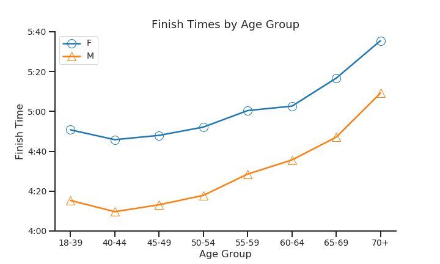

With respect to age groups, we can see that the the 40-44 year olds are the sweet spot between age and performance. This could be due to having more race experience or just the compounding effect of years of training.

What about investigating the effect of race experience on finish times? Since we have data spanning multiple years, this allows us to check for repeat runners: runners in 2019 who’ve raced at least once between 2014-2018. Runners were matched if they had the same name, country, and belonged to the same age category or the age category right below to account for aging; for example, (Jane Doe, USA, 40-44) would match to (Jane Doe, USA, 40-44) or (Jane Doe, USA, 18-39), so the matching may not be perfect. Roughly 21% of the 41,000+ 2019 runners fell into this category.

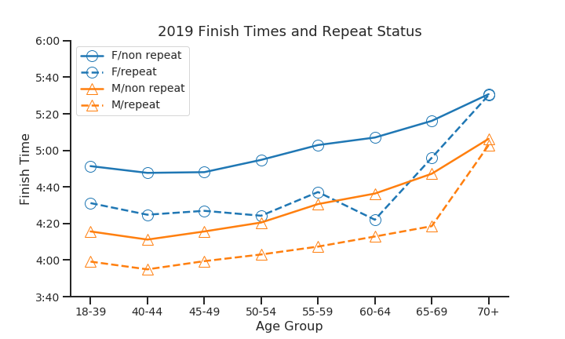

The effect is clear: repeat runners are consistently faster on average than their non-repeat counterparts across all age groups except for the 70+ category. It’s fairly surprising to see how consistent the differential is: respectively, repeat men and women were 17 and 21 min faster on average.

More surprisingly, we can even see that repeat female runners between 60-64 outperformed their non-repeat male counterparts. In fact, they’re almost as fast their repeat male counterparts! This can be attributed to selection bias - since the number of repeat female marathoners aged 60-64 is a relatively small group, you’re likely to be just as if not more competitive than even the male 60-64 repeat runners.

# Split Consistency and Coefficient of Variation

One of the main reasons why I chose to analyze London was the availibility of 5K split data (the time differential between every 5K of the race, from start to 42.2K). Using this, we can immediately calculate the paces of each runner as they progress through the race. I needed some metric to summarize the ‘consistency’ of a runner. A consistent runner should run all of their 5K splits close to their overall average marathon pace.

One could compute the standard deviation of a runner’s paces, but consider the following two runners in a 3 mile race:

| Runner | Mile 1 | Mile 2 | Mile 3 | Avg |
| --- | --- | --- | --- | --- |
| A | 7:20 | 7:30 | 7:40 | 7:30 |
| B | 4:20 | 4:30 | 4:40 | 4:30 |

$$CoV (\%) = \frac{std_X}{mean_X} \times 100$$

Now we can make meaningful comparisons between runners.

| Runner | Mile 1 | Mile 2 | Mile 3 | Avg | CoV |
| --- | --- | --- | --- | --- | --- |
| A | 7:20 | 7:30 | 7:40 | 7:30 | .22 |
| B | 4:20 | 4:30 | 4:40 | 4:30 | .37 |

Indeed, runner A has the lower CoV, which reflects that they ran more consistently. We can now continue with the analysis!

These are the results of calculating the CoV for every runner based on their 5K, 10K, etc. up to their 42.2K splits. We can then throw this into a histogram to view the distribution of the CoV.

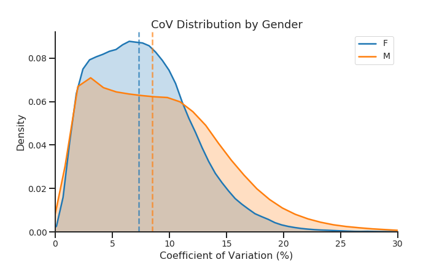

What about repeat runners?

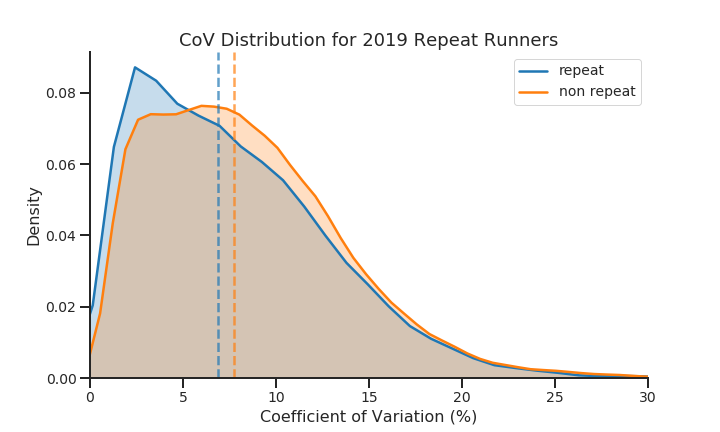

What about for elite runners?

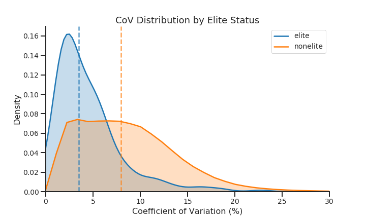

It’s no surprise that elites are more consistent than nonelite runners. Conventional running wisdom says that optimal race times come as a result of even pacing. We will explore this later down below!

Things get more interesting when you stratify runners by their finish quartile (with 1,2,3,4 corresponding to the top (25, 50, 75, 100)%) and gender.

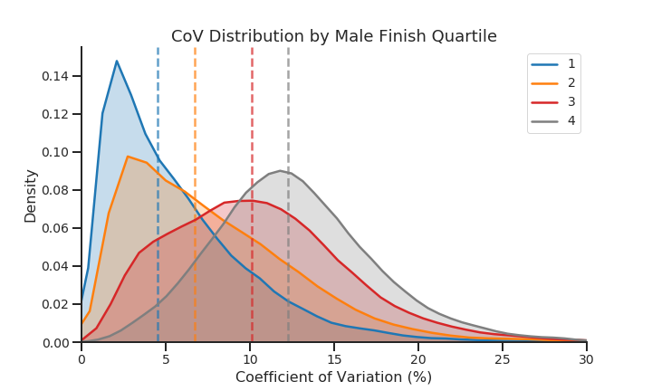

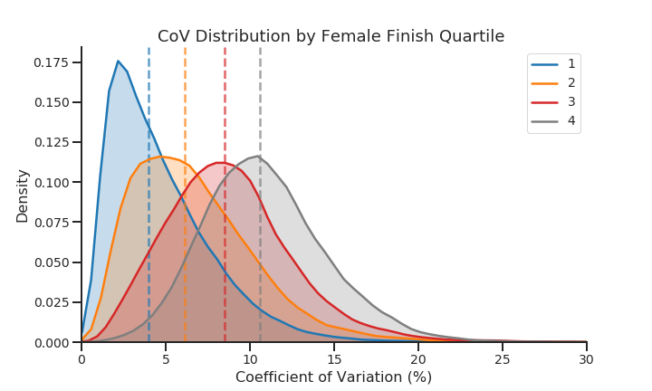

This tells us that runners who finish faster are more consistent, which comes at no surprise. However, keep in mind that these are just descriptive statistics.

Now we examine the effect of age on consistency and finish times.

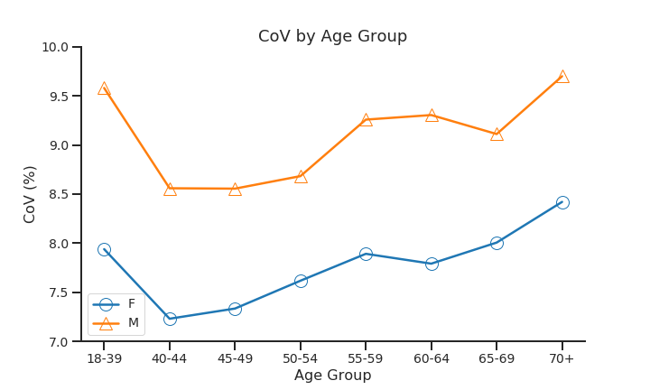

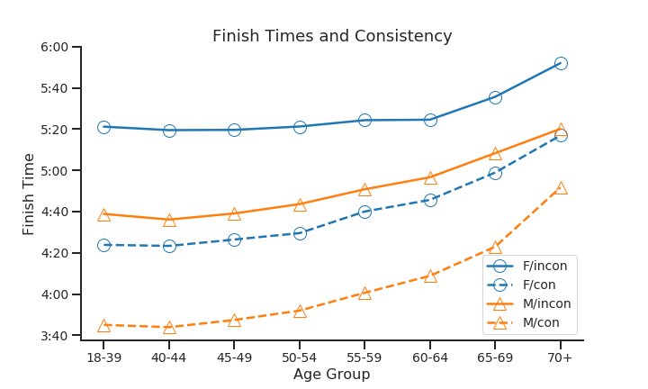

Again, we see that the 40-44 and 45-49 groups are not only the fastest on average, but also the most consistent; on the other hand, the youngest runners are just as inconsistent as the oldest runners!

Additionally, we can see that the consistent female runners are faster than inconsistent male runners across all age groups. This is to be expected, as consistent runners are more likely to be faster than inconsistent runners. Experience and consistency clearly have a profound impact on performance; this is obvious! But hopefully these results justify my choice of a consistency metric.

# Negative vs Positive Splits? What about Even?

A common point of racing discussion is whether you should run the first half of your race slower, faster, or at the same pace as your second half. There is no good answer to this - in just about every event from the 800m to the marathon, world records have been set with all 3 combinations. However there is a general consensus that the longer the race, the more beneficial an even or negative split becomes. With the marathon distance, this becomes of crucial importance: there is a common phenomenon of ‘hitting the wall,’ which is when your body runs out of fuel (glycogen) in the later stages of the race. For some, it results in being forced to walk; for others, it results in catastrophic shutdown and injury. If you go out too fast, this can severely shut you down in the later stages of the race.

First, due to the extreme weather conditions of the 2018 race, I have excluded those results from this analysis (since the rising temperature of the day almost invariably forces a positve split strategy). However, it’s worth noting that when the results were included, it didn’t change the distribution of split types.

With that in mind, let’s dive in.

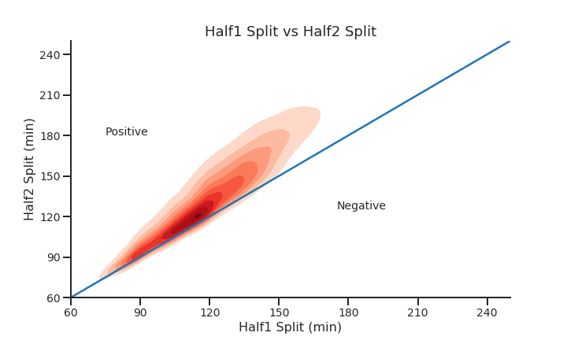

The results are telling: the vast majority of people positive split, whether by choice or necessity.

But what’s the best way to define an even split? I chose to look at a runner’s split difference (half2 - half1) divided by their finish time, in other words the split difference percentage. A positive split difference results in a positive split difference %, and likewise with negative. I then defined an even split as a split difference % between -1% and 1%, which led to roughly 10% of runners being categorized as even split runners.

This helps put into perspective how few runners ran a true negative split.

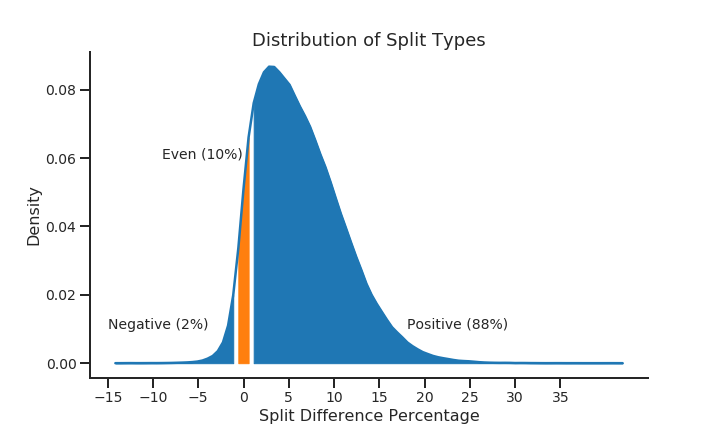

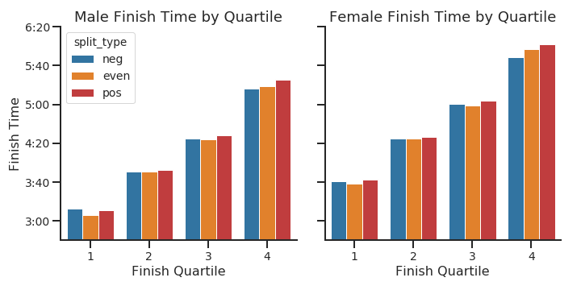

However, it’s not clear which of negative or even splits wins. We can see that even splits are only significantly faster (p<.003) for the first quartile finishers, but not in any other category.

If we expand our split profiles to the top 3 finishers in each age category, the results are more striking.

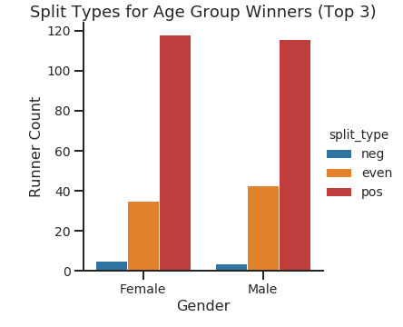

Even the fastest runners across gender and age run positive splits. So you shouldn’t feel too bad in your next race if your race strategy doesn’t pan out the way you’d like; very, very few people run true negative or even split marathons.

# Conclusions

TL;DR:

Of course, most of the results are descriptive statistics, so please take them with a grain of salt. That said, by stratifying across various categories (age, gender, consistency, finish times), we have provided some substantial evidence towards the relationship between pacing and performance, which have also been observed through analyses of many other major marathons. This is just another data point toward the collective, sage advice of ‘don’t run positive splits.’

# Final Remarks

One final note: London 2020 features a highly anticipated matchup between two running greats while also giving us a preview for the 2020 Olympic Marathon race in Japan. Eliud Kipchoge, the current men’s marathon world record holder at 2:01:39 and the only person to run below 2:00 for the marathon distance, will face off against arguably the greatest distance runner of all time, Kenenisa Bekele, who holds both the 5K and 10K world records and ran the second fastest marathon of all time at 2:01:41 by a mere 2 seconds.